# Homework 6

# Solution Sample

## Part 1: Exam-Style Questions

### Problem 1.1

Compute $A$ and $\mathbf{b}$.

### Answer

The only entry of $A$ that does not involve the second component of $\nabla J$, which is zero, is

$$ a_{11} = 9 \cdot 10 \cdot 10 = 900 $$

so that

$$ A = \left[\begin{array}{cc} 900 & 0\\0 & 0 \end{array}\right]\;. $$

Similarly, only the first component of $\mathbf{b}$ is nonzero:

$$ b_1 = 9 \cdot 10 \cdot 1 = 90 $$

and

$$ \mathbf{b} = \left[\begin{array}{c} 90\\0 \end{array}\right]\;. $$

### Problem 1.2

Does the feature at $\mathbf{x}_I$ suffer from the aperture problem? Briefly justify your answer.

### Answer

Yes, because $A$ is rank-deficient. We can also see this directly from $\nabla J$, since all gradients point in the same (horizontal) direction.

### Problem 1.3

Give the minimum-norm solution $\mathbf{x}_0$ to the linear system

$$ A\mathbf{x} = \mathbf{b}\;. $$

### Answer

This system leaves the second component of $\mathbf{x}_0$ undetermined. We set this component to zero to obtain the minimum norm solution

$$ \mathbf{x}_0 = \left[\begin{array}{c} 90/900\\0 \end{array}\right] = \left[\begin{array}{c} 0.1\\0 \end{array}\right]\;. $$

### Problem 1.4

Assume that further iterations of the Lucas-Kanade algorithm do not change the solution $\mathbf{x}_0$ much. Does your answer to the previous question imply that the image motion between $I$ and $J$ at $\mathbf{x}_I$ is approximately horizontal? Briefly justify your answer.

### Answer

No. The second component of $\mathbf{x}_0$ could be anything, so the vector as a whole could be any point on the line $x_1 = 0.1$. This is the aperture problem at work.

### Problem 1.5

[Questions from now on no longer pertain to the scenario above.]

Give the simplest example you can think of of two rotation matrices $R_1$ and $R_2$ in $\mathbb{R}^3$ that commute with each other. Two matrices $A$ and $B$ commute if $AB = BA$. There is no need to prove the correctness of your answer.

### Answer

The identity is a rotation matrix, and commutes with any other matrix of appropriate size. Thus, let for instance

$$ R_1 = I \;\;\;\mbox{and}\;\;\; R_2 = \left[\begin{array}{ccc}1 & 0 & 0\\0 & 0 & 1\\0 & -1 & 0 \end{array}\right]\;. $$

Many other answer are possible, but the matrices must be rotations for full credit.

### Problem 1.6

Give the simplest example you can think of of two rotation matrices $R_1$ and $R_2$ in $\mathbb{R}^3$ that do *not* commute with each other.

### Answer

You can almost pick two matrices at random. For instance,

$$ R_1 = \left[\begin{array}{ccc} 1 & 0 & 0\\0 & 0 & 1\\0 & -1 & 0 \end{array}\right] \;\;\;\mbox{and}\;\;\; R_2 = \left[\begin{array}{ccc} 0 & 1 & 0\\-1 & 0 & 0\\0 & 0 & 1 \end{array}\right]\;. $$

Again, many other answer are possible, but the matrices must be rotations for full credit.

### Problem 1.7

A certain camera has the following intrinsic parameters:

- A 10 mm focal distance
- Rectangular pixels, 2.5 micron wide and 2 micron tall (one mm is 1000 micron)
- A camera sensor with 4000 pixels horizontally and 3000 vertically
- The principal point is at image point $\boldsymbol{\pi} = (2000, 1500)$ pixels (horizontal, vertical)
- No distortion

The world reference system is the same as the camera's canonical reference system, except that the units for the axes are in centimeters. A point $\mathbf{X}$ has coordinates (-20, 10, 100) centimeters in the world reference system.

Give the coordinates in the *pixel image* reference system of the projection $\boldsymbol{\xi}$ of $\mathbf{X}$. Show your calculations.

[The pixel image reference system measures image coordinates in pixels, and its origin is in the upper left corner of the image.]

### Answer

The coordinates of the projection of $\mathbf{X}$ in the canonical image system are

$$ \mathbf{x} = \frac{1}{X_3} \left[\begin{array}{c} X_1\\X_2 \end{array}\right] = \frac{1}{100} \left[\begin{array}{r} -20\\10 \end{array}\right] = \left[\begin{array}{r} -0.2\\0.1 \end{array}\right] \;. $$

(so the units for $\mathbf{X}$ do not matter!). Since the pixels are 2.5 by 2 micron, there are

$$ s_1 = \frac{1000}{2.5} = 400 $$

pixels per millimeter horizontally and

$$ s_2 = \frac{1000}{2} = 500 $$

pixels per millimeter vertically. Therefore, the coordinates of $\boldsymbol{\xi}$ are

$$ \boldsymbol{\xi} = f \left[\begin{array}{cc} s_1 & 0\\0 & s_2 \end{array}\right] \mathbf{x} + \boldsymbol{\pi} = \left[\begin{array}{c} 10 \cdot 400 \cdot -0.2 + 2000\\ 10 \cdot 500 \cdot 0.1 + 1500 \end{array}\right] = \left[\begin{array}{c} 1200\\2000 \end{array}\right] \;\mbox{pixels.} $$

### Problem 1.8

This and the subsequent two problems refer to a camera pair with the following essential matrix:

$$ E = \left[\begin{array}{rrr} 0 & 0 & 0\\ 0 & 0 & - 1\\ 0 & 1 & 0 \end{array} \right] $$

For the same camera pair as in problem 1.8, give one possible value for the unit-norm vector $\mathbf{t}$ that points from the first camera to the second and for the rotation matrix $R$ between the two cameras. Both $\mathbf{t}$ and $R$ are expressed in first-camera coordinates. Justify your answer briefly.

[Hint: Think, do not calculate. What does $[\mathbf{t}]_{\times}$ look like?]

### Answer

This essential matrix has the form

$$ E = [\mathbf{t}]_{\times} \;\;\;\mbox{where}\;\;\; \mathbf{t} = \left[\begin{array}{c} 1\\0\\0 \end{array}\right] \;. $$

Since $E = R\,[\mathbf{t}]_{\times}$, we have

$$ \mathbf{t} = \pm \left[\begin{array}{c} 1\\0\\0 \end{array}\right] \;. $$

If the positive sign is chosen for $\mathbf{t}$, then $R$ is the identity matrix,

$$ R = I\;. $$

With the negative sign for $\mathbf{t}$,

$$ R = \left[\begin{array}{rrr} 1 & 0 & 0 \\ 0 & -1 & 0\\ 0 & 0 & -1 \end{array} \right] \;. $$

### Problem 1.10

For the same camera pair as in problem 1.8, a point in the second image has coordinates

$$ \mathbf{b} = \left[\begin{array}{c} 0.5\\1\\1 \end{array} \right] $$

in the canonical *camera* reference system (units are focal distances). Write the equation of the epipolar line of $\mathbf{b}$ in the canonical *image* reference system of the first camera. Show your derivation.

[Remember that the canonical image coordinates of a point are the same as its first two canonical camera coordinates.]

### Answer

From the epipolar constraint equation

$$ \mathbf{b}^T E \mathbf{a} = 0 $$

we obtain

$$ \left[\begin{array}{rrr} 0.5 & 1 & 1 \end{array}\right] \left[\begin{array}{rrr} 0 & 0 & 0\\0 & 0 & -1\\0 & 1 & 0 \end{array}\right] \mathbf{a} = \left[\begin{array}{rrr} 0 & 1 & -1 \end{array}\right]\mathbf{a} = 0 \;. $$

The third coordinate of $\mathbf{a}$ is 1, so that we obtain the equation

$$ x_2 = 1 \;, $$

a horizontal line one focal distance below the principal point.

## Part 2: Window Tracking

```
Restarting frame reader for freeThrow/img
```

[figure not shown]

[figure not shown]

```python
from urllib.request import urlopen
from shutil import copyfileobj
from tempfile import NamedTemporaryFile as namedTempFile
from imageio import imread
from zipfile import ZipFile
from os.path import exists

def frameReader(basename, first, last, fmt = r'{}{:03d}.pgm'):
    print('Restarting frame reader for', basename)
    for f in range(first, last+1):
        filename = fmt.format(basename, f)
        if f % 10 is 0: print(f, end=' ')
        yield imread(filename).astype(float) / 255.0

def freeThrowReader():
    url = 'https://www2.cs.duke.edu/courses/spring19/compsci527/homework/6/'
    basename = 'freeThrow'
    zipname = basename + '.zip'
    if not exists(basename):
        print('Retrieving', zipname, 'from', url)
        with urlopen(url + zipname) as response:
            with namedTempFile(delete=False) as tmpFile:
                copyfileobj(response, tmpFile)
        with ZipFile(tmpFile.name, 'r') as zip:
            zip.extractall()
        print('Stored video in the local data directory', basename)
    return frameReader(basename + '/img', 2, 129)

from matplotlib import pyplot as plt
%matplotlib inline

# Show a couple of frames
ftr = freeThrowReader()
for i in range(2):
    frame = next(ftr)
    plt.imshow(frame, cmap=plt.cm.gray)
    plt.show()
```

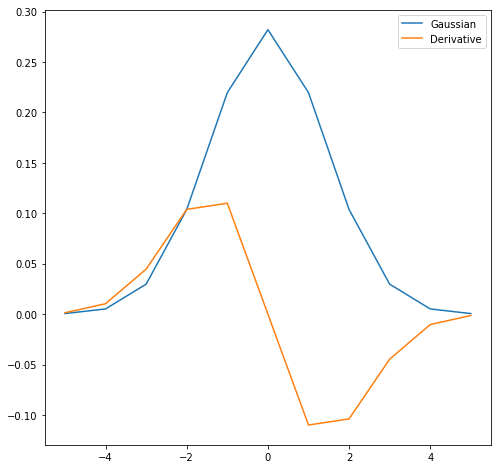

```python
import numpy as np

def Gauss(hWin):
    winSize, sigma = 2 * hWin + 1, hWin / 2.5
    x = np.linspace(-hWin, hWin, winSize)
    g = np.exp(- np.power(x, 2) / np.power(sigma, 2))
    ramp = -x
    d = ramp * g
    return g / np.sum(g), d / np.dot(ramp, d), x

hGaussWin = 5
g, d, x = Gauss(hGaussWin)
plt.figure(figsize=(8, 8))
plt.plot(x, g, label='Gaussian')
plt.plot(x, d, label='Derivative')
plt.legend()
plt.show()
```

[figure not shown]

```python
def row(x):
    assert x.ndim == 1, 'Input must be a 1-dimensional array'
    return np.expand_dims(x, 0)

def column(x):
    assert x.ndim == 1, 'Input must be a 1-dimensional array'
    return np.expand_dims(x, 1)

from scipy.signal import convolve2d as conv

def gradient(img, hWin):
    g, d, _ = Gauss(hWin)
    gr = conv(conv(img, row(g), 'same'), column(d), 'same')
    gc = conv(conv(img, row(d), 'same'), column(g), 'same')

    return (gr, gc)

from skimage.color import hsv2rgb

def colorCoding(x, y):
    z = x + 1j * y
    mag, ang = np.absolute(z), np.angle(z)
    mn, mx = np.min(mag), np.max(mag)
    hsv = np.zeros((*x.shape, 3), dtype=float)
    hsv[..., 0] = (ang + np.pi) / (2.0 * np.pi)
    hsv[..., 1] = (mag - mn) / mx
    hsv[..., 2] = 1.0
    return hsv2rgb(hsv)

# Display a color coding of the gradient of the last frame read
gr, gc = gradient(frame, hGaussWin)
plt.figure(figsize=(8, 8))
plt.imshow(colorCoding(gc, gr))
plt.title('color coding of input-frame gradient')
plt.show()
```

```python
parms = {}
parms['hGaussWin'] = 3
parms['hFeatureWin'] = 5
parms['lambdaPercentile'] = 90
parms['maxNFeatures'] = 1000
parms['minFeatureDistance'] = 5
parms['minStep'] = 0.01
parms['maxIterations'] = 30
```

### Problem 2.1

Write a function with header

```
def lambdaMin(f, parms):
```

that takes a single frame `f` out of a video sequence and returns a floating-point image `lambda2` of the same size as `f`. The value of every pixel in `lambda2` is the smaller eigenvalue of the matrix $A_f$ defined in the class notes on window tracking. [Recall that the eigenvalue of a $2\times 2$ matrix can be computed in closed form, as shown in Algorithm 2 in the class notes on window tracking.]

Show your code and a binary image that is white wherever `lambda2 > lambda0` and black elsewhere. The image `f` for this experiment is the image `frame` defined earlier (the second frame returned by `freeThrowReader`). The threshold `lambda0` is the percentile of `lambda2` specified in `parms`.

Make your figure with `plt.figure(figsize=(8, 8))`. Give your figure a title that shows the value of `lambda0` with 5 digits after the decimal period.

### Answer

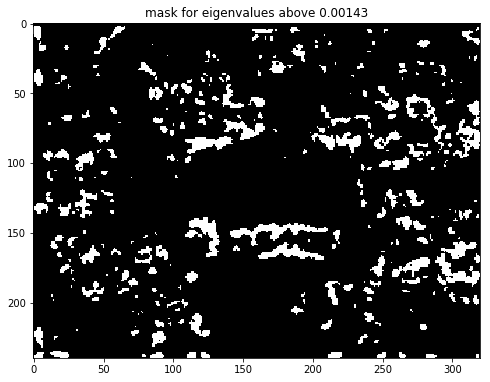

```python
def lambdaMin(f, parms):
    hGrad, hWin = parms['hGaussWin'], parms['hFeatureWin']
    def integrate(x):
        g, _, _ = Gauss(hWin)
        return conv(conv(x, row(g), 'same'), column(g), 'same')

    gr, gc = gradient(f, hGrad)
    Grr, Grc, Gcc = integrate(gr * gr), integrate(gr * gc), integrate(gc * gc)
    lambda2 = (Grr + Gcc - np.sqrt(np.power(Grr - Gcc, 2) + 4 * np.power(Grc, 2))) / 2
    return lambda2

lambda2 = lambdaMin(frame, parms)
lambda0 = np.percentile(lambda2, parms['lambdaPercentile'])

plt.figure(figsize=(8, 8))
plt.imshow(lambda2 >= lambda0, cmap=plt.cm.gray)
plt.title('mask for eigenvalues above {:.5f}'.format(lambda0))
plt.show()
```

### Problem 2.2

```python
def outside(p, shape, parms):
    margin = parms['hGaussWin'] + parms['hFeatureWin']
    out = p[0] < margin or p[0] > shape[0] - margin
    return out or p[1] < margin or p[1] > shape[1] - margin
```

Write a function with header

```
def goodFeatures(img, parms):
```

that computes as many good features to track as possible by the algorithm described in the class notes. We are not asking to find the absolute maximum number of features: The greedy method described in the class notes will suffice.

Good features

- Have a value of `lambda2` greater than the percentile specified in `parms`
- Are at most `parms['maxNFeatures']` in number
- Are spaced at least `parms['minFeatureDistance']` apart
- Are not too close to the margins of `img`, as determined by `outside`

Show your code and the centers of the windows found in `frame` (same as earlier) superimposed as red crosses. Make your figure with `plt.figure(figsize=(8, 8))`.

Also state the number of features your code found (these will be fewer than `parms['maxNFeatures']`).

### Answer

[figure not shown]

```
435 features found
```

```python
def goodFeatures(img, parms):
    lambda2 = lambdaMin(img, parms)
    lambda0 = np.percentile(lambda2, parms['lambdaPercentile'])
    row, col = np.nonzero(lambda2 >= lambda0)
    lambda2 = lambda2[row, col]
    idx = np.argsort(-lambda2)
    lambda2, row, col = lambda2[idx].tolist(), row[idx].tolist(), col[idx].tolist()
    goodRow, goodCol, goodLambda2 = [], [], []
    while len(goodLambda2) < parms['maxNFeatures'] and len(lambda2) > 0:
        l, r, c = lambda2[0], row[0], col[0]
        if outside([r, c], img.shape, parms):
            rem = [0]
        else:
            goodLambda2.append(l)
            goodRow.append(r)
            goodCol.append(c)
            d = parms['minFeatureDistance']
            rem = []
            for idx in range(len(row)):
                if np.abs(row[idx] - r) < d and np.abs(col[idx] - c) < d:
                    rem.insert(0, idx)
        for idx in rem:
            lambda2.pop(idx)
            row.pop(idx)
            col.pop(idx)

    p = np.array([goodRow, goodCol]).transpose().astype(float)
    lambda2 = np.array(goodLambda2)

    return p, lambda2

p, lambda2 = goodFeatures(frame, parms)

plt.figure(figsize=(8, 8))
plt.imshow(frame, cmap=plt.cm.gray)
plt.plot(p[:, 1], p[:, 0], 'xr')
plt.show()
print(len(p), 'features found')
```

### Problem 2.3

Write a function with header

```
def lucasKanade(f, g, p, parms):
```

that implements the Lucas-Kanade algorithm as described in the class notes, and with the parameters specified in `parms`. The input arguments `f` and `g` are two consecutive frames of a video sequence, and `p` is a `numpy` array of shape `(2,)` that contains the row and column coordinates of the feature point (center of a feature window) in `f` to be tracked. The function returns a `numpy` array of shape `(2,)` that contains the row and column coordinates of the corresponding feature point in `g` (not the displacement).

Please keep in mind that the description given in Algorithm 1 on page 7 of the notes is only a conceptual trace. In Python, it is easier to look at the equations in section 2 of the notes, and implement those.

Show your code and the result of the test code given below. The code assumes that the file `data.pkl` provided with this assignment is in the same directory as this notebook.

### Answer

```python
from scipy.interpolate import RectBivariateSpline as interpolate

def lucasKanade(f, g, p, parms):

    def window(spline, p, hGaussWin, hFeatureWin):
        def crop(win, tail):
            return win[tail:-tail, tail:-tail]
        tail = hGaussWin + hFeatureWin
        winSize = 2 * tail + 1
        rows = np.linspace(p[0] - tail, p[0] + tail, winSize)
        cols = np.linspace(p[1] - tail, p[1] + tail, winSize)
        win = spline(rows, cols).astype(np.float32)
        gr, gc = gradient(win, hGaussWin)
        gr, gc = crop(gr, hGaussWin), crop(gc, hGaussWin)
        win = crop(win, hGaussWin)
        return win, gr, gc

    if outside(p, f.shape, parms):
        return None

    hGaussWin, hFeatureWin = parms['hGaussWin'], parms['hFeatureWin']
    w, _, _ = Gauss(hFeatureWin)
    w = column(w) * row(w)

    rows = np.arange(f.shape[0], dtype='float')
    cols = np.arange(f.shape[1], dtype='float')
    fSpline = interpolate(rows, cols, f, kx=1, ky=1)
    gSpline = interpolate(rows, cols, g, kx=1, ky=1)

    fWin, _, _ = window(fSpline, p, hGaussWin, hFeatureWin)

    A, b = np.zeros((2, 2)), np.zeros(2)
    done, lost, iteration = False, False, 0
    q = p.copy()

    while not done and not lost:
        gWin, gWinGr, gWinGc = window(gSpline, q, hGaussWin, hFeatureWin)
        A[0][0] = np.sum(gWinGr * gWinGr * w)
        A[0][1] = np.sum(gWinGr * gWinGc * w)
        A[1][1] = np.sum(gWinGc * gWinGc * w)
        A[1][0] = A[0][1]
        diff = fWin - gWin
        b[0] = np.sum(gWinGr * diff * w)
        b[1] = np.sum(gWinGc * diff * w)
        s, _, _, _ = np.linalg.lstsq(A, b, rcond=None)
        q += s
        iteration += 1

        done = np.linalg.norm(s) < parms['minStep']
        lost = np.linalg.norm(q - p) > hFeatureWin
        lost = lost or iteration > parms['maxIterations']
        lost = lost or outside(q, g.shape, parms)

    if lost:
        q = None

    return q
```

```python
import pickle
try:
    with open('data.pkl', 'rb') as file:
        data = pickle.load(file)
    f, g, p, qTrue = data['f'], data['g'], data['p'], data['q']
    q = np.empty_like(qTrue)
    for k in range(p.shape[0]):
        q[k] = lucasKanade(f, g, p[k], parms)
    np.set_printoptions(precision=4, suppress=True)
    print('Tracking errors (in pixels):')
    print(q-qTrue)
    np.set_printoptions()
except NameError:
    pass
```

```
Tracking errors (in pixels):
[[-0.0011 -0.0002]
 [ 0.0005  0.002 ]
 [ 0.0002 -0.0009]
 [ 0.0012 -0.0005]
 [ 0.     -0.0015]
 [ 0.0012  0.0034]
 [-0.0012  0.0011]
 [-0.0001  0.0004]
 [ 0.0002  0.    ]]
```

### Problem 2.4

Write a function with header

```
def trackPoints(videoReader, parms):
```

that tracks all good features found in the first frame of the video generated by the reader, and with the given parameters. Your function should use your own `goodFeatures` and `lucasKanade`.

The output from `trackPoints` should be a list of lists. There is one inner list for each point found by `goodFeatures` in the first frame of the video. This inner list lists the coordinates of that point in every frame (as a `numpy` array), until the point is lost. When the point is lost, the corresponding list entry is `None`, and the list stops after that entry.

Show your code and display the results from the call

```
tracks = trackPoints(freeThrowReader, parms)
```

To display the results, produce two images. The first one is the *fill pattern* of the result. Let $m$ be the length of the longest list in `tracks`, and let `n` be the length of `tracks`. Then, the fill pattern is an $m\times n$ binary matrix whose entry $(i, j)$ is equal to 1 if feature $j$ was found in frame $i$ and 0 otherwise.

Display the fill pattern as an image, using the default color map for `imshow`.

The second image you produce is the first frame of the video sequence (with `cmap=plt.cm.gray`) with the tracks superimposed as red lines. Also plot a red circle (`'or'`) at the beginning of each track.

Draw each figure in a `plt.figure(figsize=(8, 8))`.

### Answer

```
Restarting frame reader for freeThrow/img
10 20 30 40 50 60 70 80 90 100 110 120
```

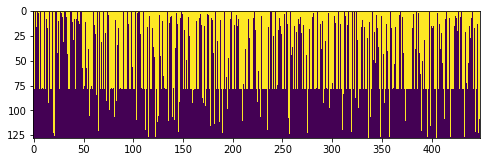

```
Restarting frame reader for freeThrow/img
```

[figure not shown]

```python
def trackPoints(videoReader, parms):
    reader = videoReader()
    f = next(reader)
    p0, _ = goodFeatures(f, parms)
    tracks = [[point] for point in p0]
    for g in reader:
        foundPoint = False
        for t in tracks:
            p = t[-1]
            if p is not None:
                t.append(lucasKanade(f, g, p, parms))
                foundPoint = True
        if not foundPoint:
            print('Lost all tracks')
            break
        f = g.copy()
    return tracks

tracks = trackPoints(freeThrowReader, parms)

def fillPattern(t):
    length = [len(track) for track in t]
    m, n = max(length), len(t)
    p = np.zeros((m, n))
    for k in range(n):
        p[:length[k], k] = 1
    return p

pattern = fillPattern(tracks)
plt.figure(figsize=(8, 8))
plt.imshow(pattern)
plt.show()

plt.figure(figsize=(8, 8))
ftr = freeThrowReader()
f = next(ftr)
plt.imshow(f, cmap=plt.cm.gray)
for track in tracks:
    point = track[0]
    if point is not None:
        plt.plot(point[1], point[0], 'or')
    r, c = [], []
    for point in track:
        if point is not None:
            r.append(point[1])
            c.append(point[0])
    plt.plot(r, c, 'r')
plt.show()
```

### Problem 2.5

Comment on the results. Specifically:

- Why are there few features on the basketball player?
- Describe a few features that, although detected, are either lost very soon or are not tracked correctly. Why does that happen?
- What could one do to track more features over more frames?

### Answer

The background is generally more textured than the foreground (basketball player), and this results in more features being rich enough to avoid the aperture problem in the background, at least at the scale implied by the small window size ($11\times 11$).

Most of the features on the basketball player are lost almost immediately. This is because these points on the player's t-shirt are occluded by his swinging arms and the basketball. Points on the basket backboard are also not tracked for long, presumably because they get too close to the image boundaries.

Some of the motions in the foreground are very large, and are lost soon during tracking. One could track features in a pyramid, as described in the class notes, to follow even these larger motions.

One could also detect more features by relaxing the window-overlap constraint, or by lowering the percentile for acceptable $\lambda_2$. Changing window size may also change the number of features detected, although it is not clear in which direction.